# Analysing the effects of climate change and forest disturbance on vegetation dynamics in the boreal forest

Theresa Meier, 25.04.2024

## Exploratory Analysis: FPCA for PFT *Temperate Broadleaf* with disturbances between 2015 and 2040

Patches which face a disturbance between the years **2015** and **2040** are the basis for this analysis. As a first step in the exploratory analysis, the data is represented as functions by means of a b-spline basis equivalently as for PFT *Tundra*, i.e. b-splines of order 6, penalizing the third derivative with a penalization parameter $\lambda = 1$.

### Basis Representation - Temperate Broadleaf

Figure 1 shows the chosen basis representation for *Temperate Broadleaf*.

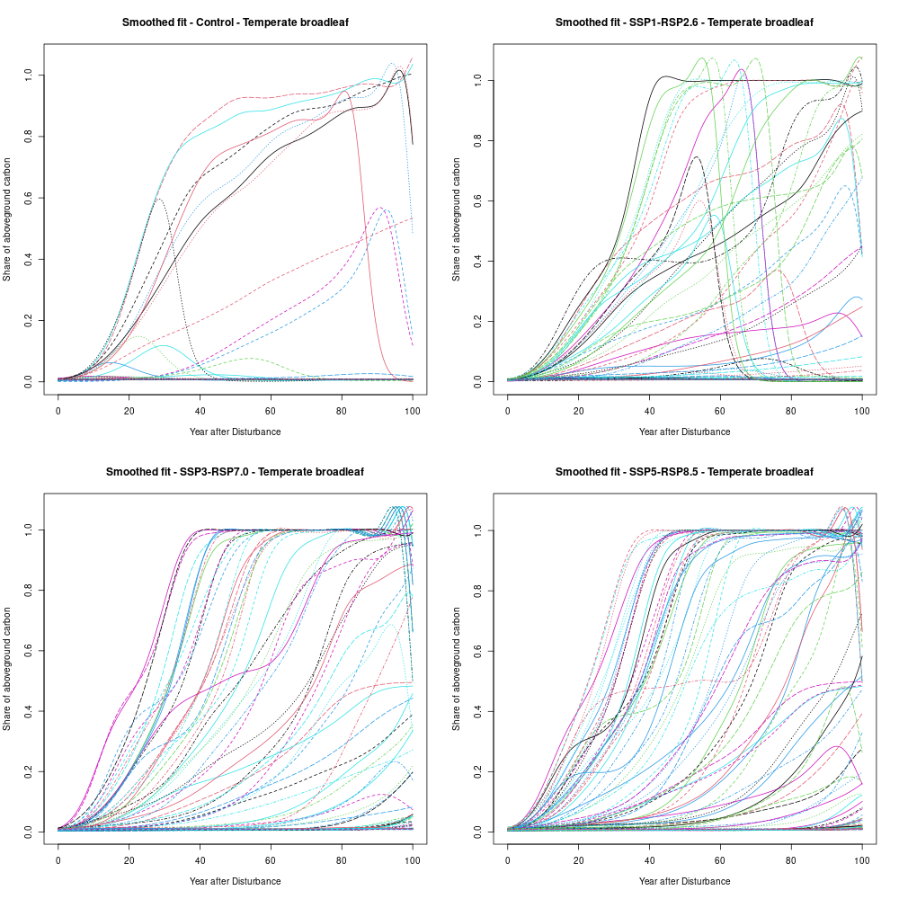

**Figure 1:** Smoothed basis representation for PFT Temperate Broadleaf and all four scenarios.

Note that there is less data available as for the other PFTs because in a lot of grid cells, the share of temperate broadleaf is constantly zero. This is not surprising in the boreal forest, since it is usally dominated by needleleaf.

### Principal Component Analysis - Temperate Broadleaf

To further analyze the data, a FPCA is run for each of the four scenarios and each of the five PFTs separately. Again, let’s take a look at the two principal components for each scenario of PFT *Temperate Broadleaf*. Figure 2 shows the principal components.

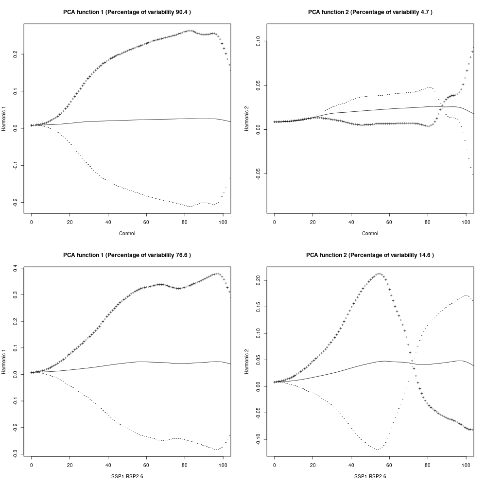

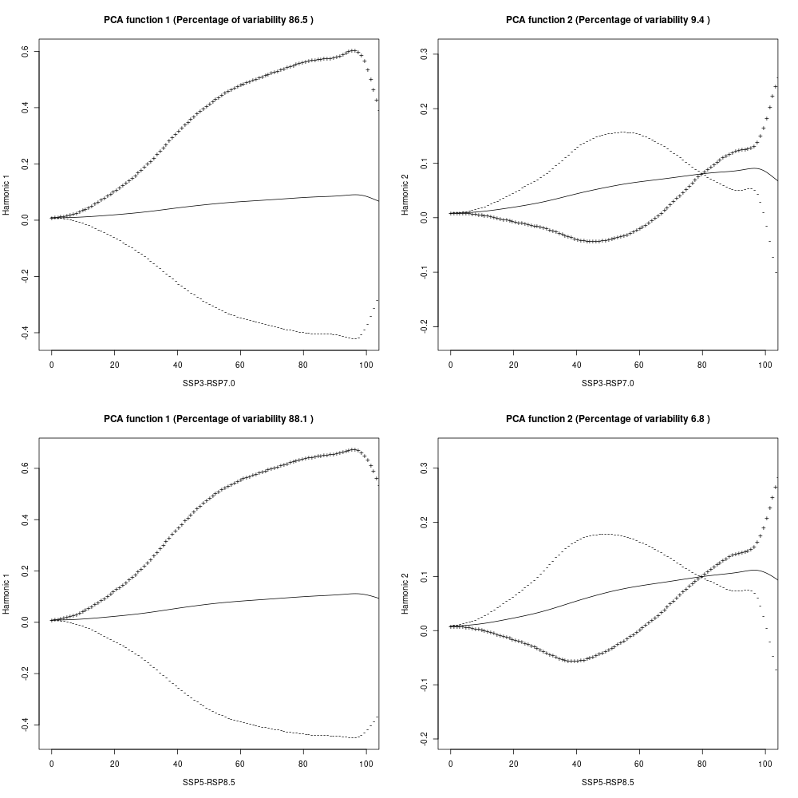

**Figure 2:** First two principal components for each scenario for PFT *Temperate Broadleaf*

For Tundra, we could see huge differences between the Control scenario and the climate scenario. Here however, the first principal components for all four scenarios are pretty similar and all reflect the same patterns: high values in the first PC stand for much higher values of above ground carbon than the mean and vice versa for low values. The second principal component mainly reflects lower values as the mean for higher PC2 scores until a break point and then higher values than the mean, vice versa for lower values of PC2. Note that the time point of the change differs among the scenarios and that this effect is reversed for the SSP1-RCP2.6 scenario (why?)!

#### With VARIMAX rotation

For a better understanding and an easier interpretation of the principal components, a VARIMAX rotation is applied. This rotation algorithm may reveal more meaningful components of variation in the data (Ramsay et al. (2009)).

Figure 3 shows the VARIMAX rotated first and second principal components for each scenario.

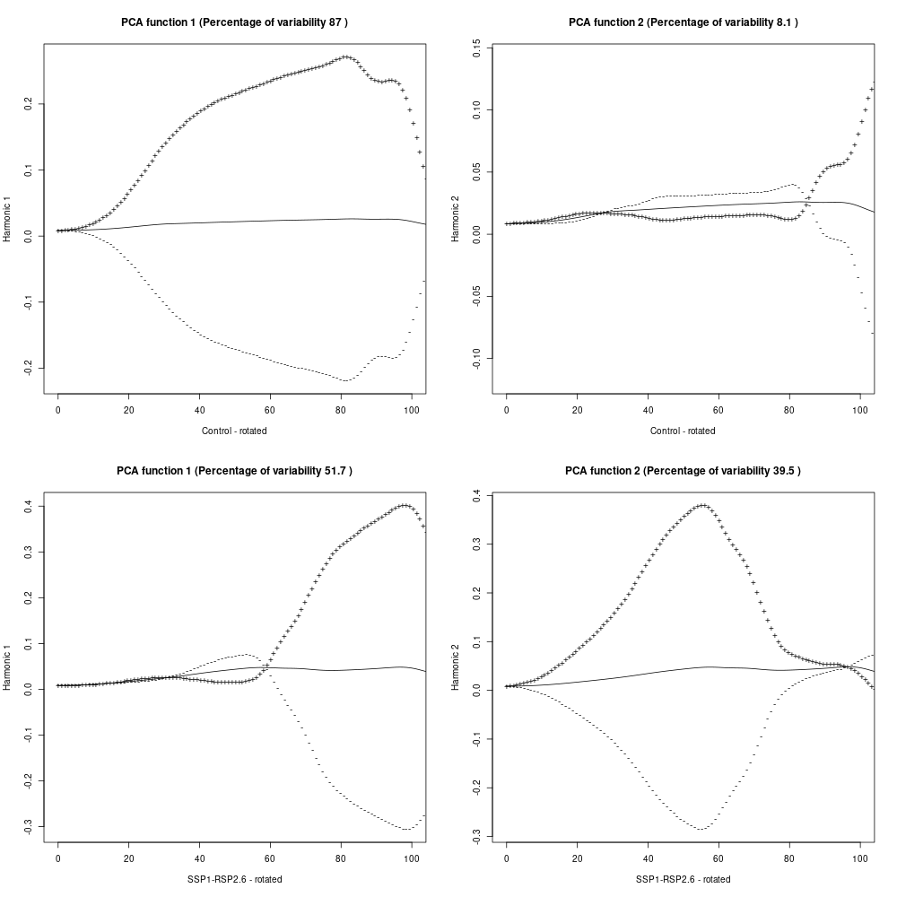

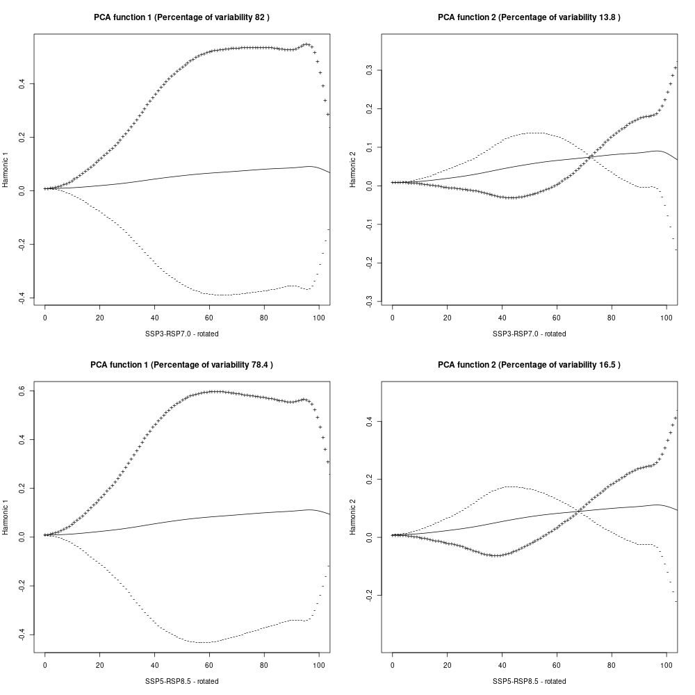

**Figure 3:** First two principal components for each scenario for PFT *Temperate Broadleaf* with VARIMAX rotation.

### Cluster detection: PC1 vs. PC2 - Temperate Broadleaf

In order to detect possible clusters in the data, i.e. the share of above ground carbon may behave in similar ways for several grid points, the two first principal components are plotted against each other for all considered cases: unrotated and VARIMAX rotated (Figure 5). The color reflects a rough classifying into regions, here continents.

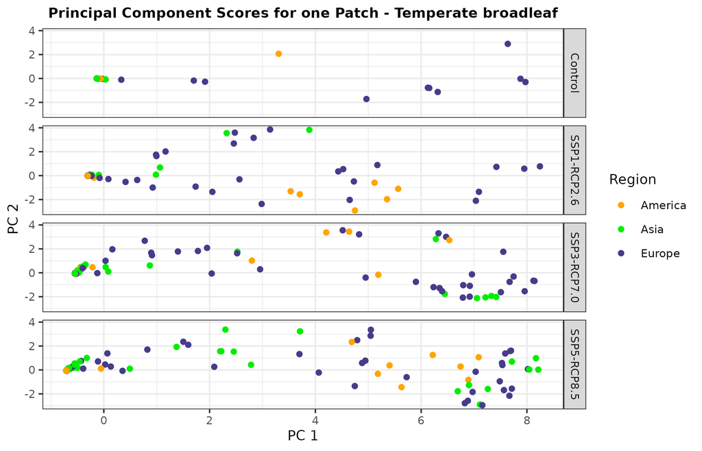

**Figure 4:** First principal component vs. second principal component for each scenario for PFT *Temperate Broadleaf*.

In Figure 4, no clustering pattern is visible at all. The scores are rather scattered and do not show clear signs of grouping. However, some similarities are present between the climate scenarios.

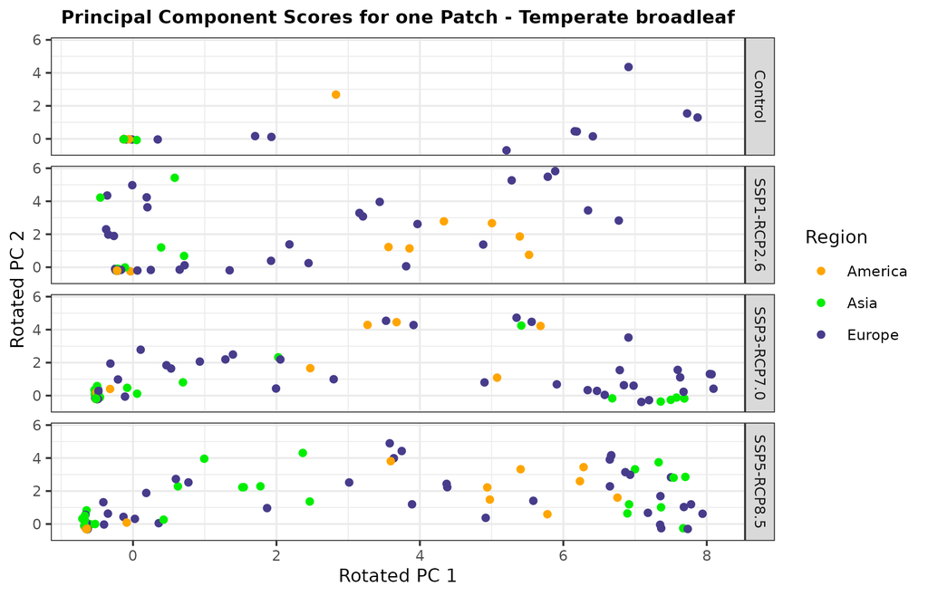

**Figure 5:** First VARIMAX rotated component vs. second VARIMAX rotated component for each scenario for PFT *Temperate Broadleaf*

## Spatial Distribution visualized in world maps

In order to get a better understanding of the spatial component of the data, Figure 6 shows how the portion of above ground carbon from year 0 to 100 after disturbance develop in each grid cell (patch 1).

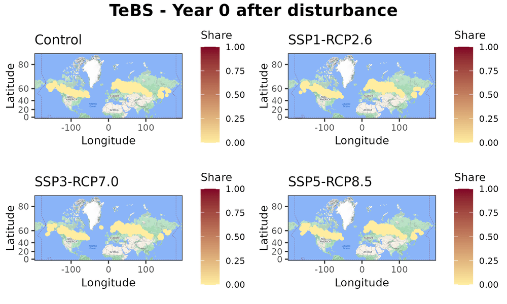

**Figure 6:** Spatial distribution of the portion of above ground carbon after distrubance for each scenario for PFT *Temperate Broadleaf*.